# Statistics with R, class 15

Interval estimation, confidence intervals, *t* distribution

Grzegorz Krajewski Faculty of Psychology University of Warsaw krajewski@psych.uw.edu.pl

5 December 2024

# Sampling distributions and estimation

## CLT and sampling distribution of mean

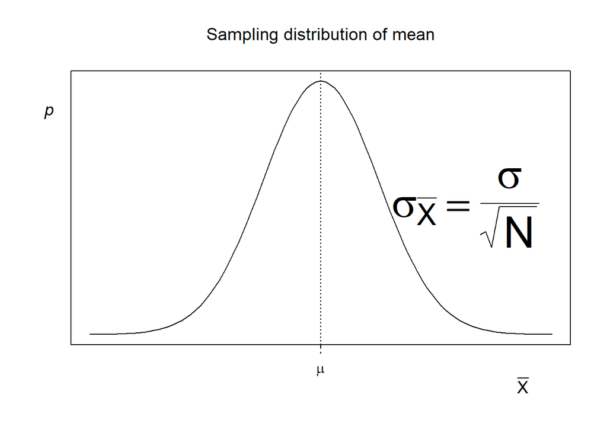

- $\bar{X} \sim N\left(\mu, \frac{\sigma^2}{N}\right)$
- What about non-normal population distributions?

## CLT and sampling distribution of mean

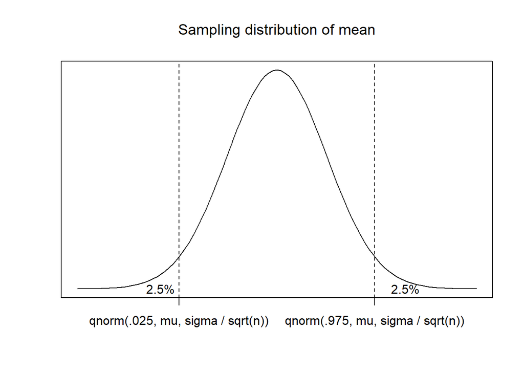

- Conventional 5%
- What are the cut-off points for IQ given sample size $N = 25$?

```r
> qnorm(c(.025, .975), 100, 15/sqrt(25))
```

## Standardised sampling distribution of mean

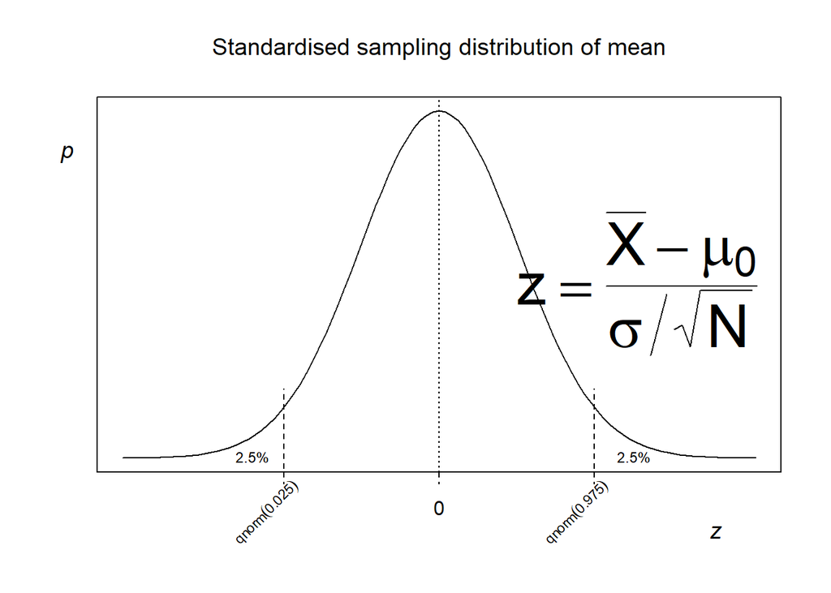

- Standardised cut-off values around `zero` (same abs. value)

## Standardised sampling distribution of mean

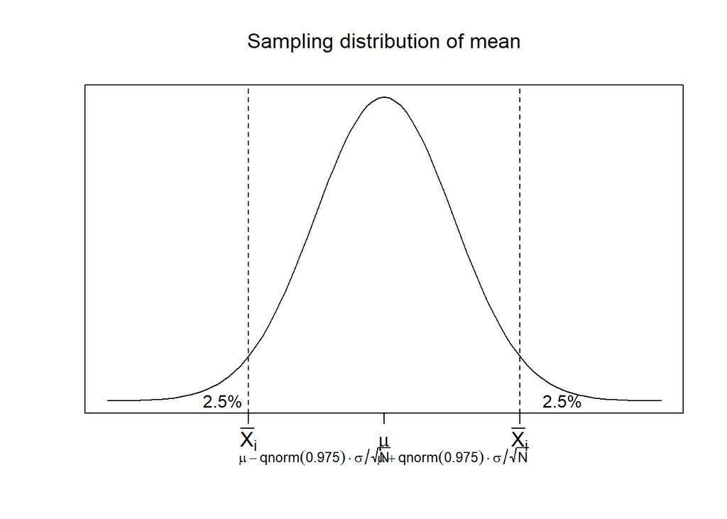

- Easily applicable to any population parameters…
- $\bar{X}_{2.5\%} = \mu \pm Z_{2.5\%} * \frac{\sigma}{\sqrt{N}}$
- … and other cut-off points (e.g., $Z_{0.5\%}$)

# Confidence intervals

## Confidence interval for population mean

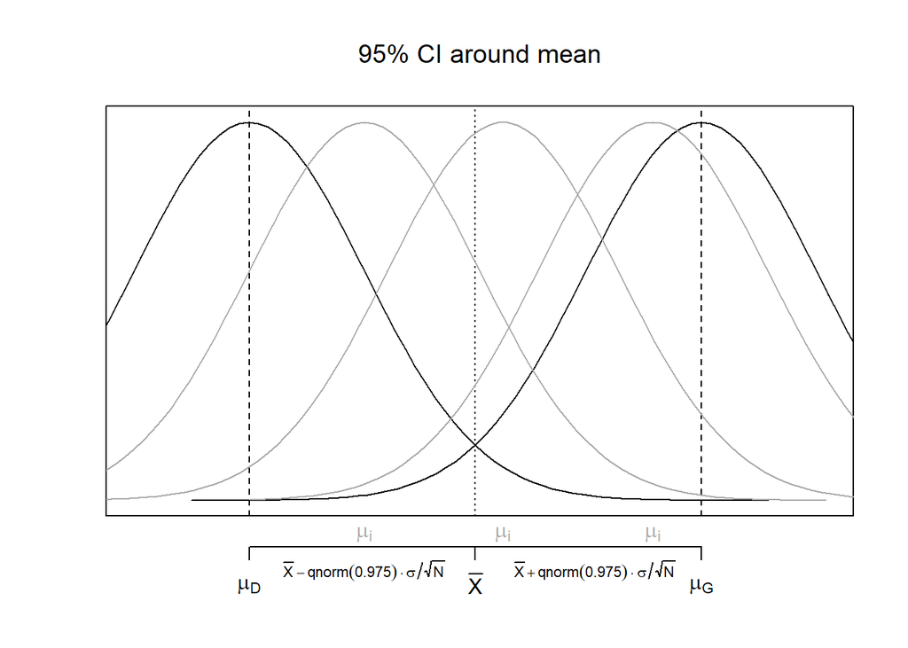

$CI_{p\%} = \bar{X} \pm Z_{p\%} * \frac{\sigma}{\sqrt{N}}$

## Exercises on CI:

- 30 CogSci students were sampled at random and their mean IQ is 117. Assuming that standard deviation in the population of CogSci students is the same as in general population, construct 99% CI around the mean. How does it relate to the general population mean IQ? What does it tell us?
- 20 Psychology students were sampled at random and their mean IQ is 105. Assuming that standard deviation in the population of Psychology students is the same as in general population, can we say with 95% confidence level that mean IQ of Psychology students differs from the general population mean IQ?

## Solutions (CI):

```r
> #Ex.1
> 117 + qnorm(.995) * 15 / sqrt(30)
> 117 - qnorm(.995) * 15 / sqrt(30)
> # General population mean outside CI
> # CogSci population different
>
> #Ex.2
> 105 + qnorm(.975) * 15 / sqrt(20)
> 105 - qnorm(.975) * 15 / sqrt(20)
> # General population mean within CI
> # Psych population not different??
```

## Simulation of CI

```r
> i <- 10000
> mu <- 100; sigma <- 15; n <- 50
> mean(replicate(i, {
+    s <- rnorm(n, mu, sigma)
+    mu >= mean(s) - qnorm(.975) * sigma/sqrt(n) &
+    mu <= mean(s) + qnorm(.975) * sigma/sqrt(n)
+ }))
```

- Analyse the code and predict its outcome
- Copy the code and run it
- How do the values of N and sigma affect CIs?

## Simulation of CI

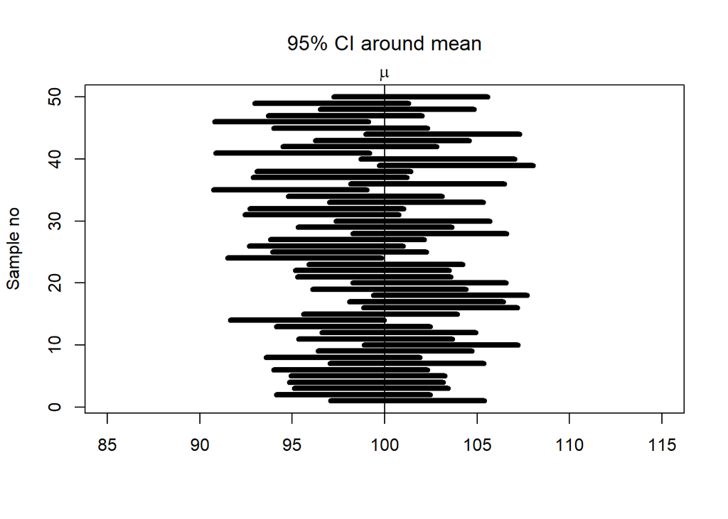

- How do the values of N and sigma affect CIs?
  - How does CIs’ width depend on them?
  - What about the frequency with which the population mean falls within the CI?
  - They affect the width of CI, never how often population mean falls within CI

# *t* distribution

## Unknown population variance

- So far we were a bit unrealistic assuming we know population sd
  - in most cases, if we did we would know the mean as well
  - What can we do about it??
- Use sample standard deviation as an estimate (could it possibly work?)
- Modify the simulation accordingly and check the outcome

## Unknown population variance

```r
> i <- 10000
> mu <- 165; sigma <- 5; N <- 20
> mean(replicate(i, {
+    s <- rnorm(N, mu, sigma)
+    mu >= mean(s) - qnorm(.975) * sd(s)/sqrt(N) &
+    mu <= mean(s) + qnorm(.975) * sd(s)/sqrt(N)
+ }))
```

- How does N affect CIs?
  - Check the outcome for $N=10$ and $N=100$
  - The actual confidence level lower than expected 95%
  - The greater N the smaller the difference
- Why is the CI width systematically underestimated?

## *t* distribution

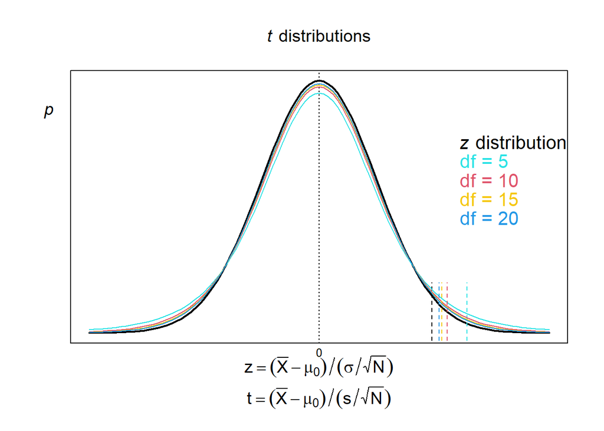

## *t* distribution

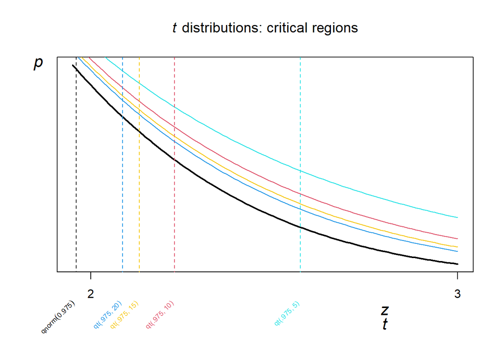

## *t* distribution

- Modify the simulation accordingly
  - using `qt()`

```r
> i <- 10000
> mu <- 165; sigma <- 5; N <- 20
> mean(replicate(i, {
+    s <- rnorm(N, mu, sigma)
+    mu >= mean(s) - qt(.975, N-1) * sd(s)/sqrt(N) &
+    mu <= mean(s) + qt(.975, N-1) * sd(s)/sqrt(N)
+ }))
```

## *t* distribution and CIs – exercise

- $CI_{p\%} = \bar{X} \pm t_{p\%}(df) * \frac{s}{\sqrt{N}}$
- 25 people were randomly sampled, their mean shoe size is 40 and the standard deviation of their shoe sizes is 3.
- Using *t* distribution, calculate the upper limit of 95% CI around mean.

```r
> 40 + qt(.975, 24) * 3 / sqrt(25)
```